# Identification of clinically relevant characteristic patterns of physical activity measured via continuous actigraphy in subjects with and without Mild Alzheimer’s

Rahul Ghosal

12/02/2021

# 1 Intoduction

The prevalent number of AD cases in the United States is projected to more than double from nearly 5 million in 2014 to nearly 14 million by 2060 and costs will rise to over $1 trillion (Alzheimer’s Association, 2020). In the absence of effective therapies to prevent or treat AD, there is growing interest in identifying cost effective biomarkers for early identification of risk for AD. Biomarkers are useful tools for identifying individuals early in disease progression who may benefit from treatments or trials, for use as surrogate end-points for clinical trials, and as a way to better understand mechanisms of disease progression to identify targets for interventions.

Non-invasive, cost-effective biomarkers are essential to improving diagnosis of AD across multiple care settings and screening large numbers of individuals to direct them into targeted clinical trials (Zvěřová, 2018). Recently, “digital” biomarkers from sensor and mobile/wearable devices (Thambisetty & Lovestone, 2010; Kourtis, Regele, Wright, & Jones, 2019) have been suggested for early detection as an alternative to fluid and imaging markers considering mounting evidence indicating that sensory and motor changes may precede neurologic and neurodegenerative diseases.

# 2 Data

Mild AD (n = 39) and cognitive normal control (CNC; n = 53) participants from the University of Kansas Alzheimer’s Disease Center Registry (KU-ADC) wore a GT3x+ accelerometer for 24 hours a day for seven days. The objective is to explore the efficacy of continuously measured physical activity to differentiate between mild AD and CNC participants and study its association with cognitive performance. Participant demographics are displayed in Table 1 below.

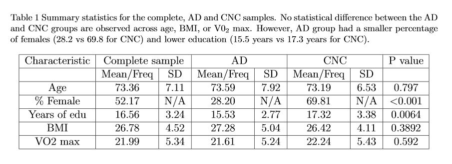

# 3 Parametric Analysis Using Cosinor Modelling

We consider paraetric analysis of actigraphy data using Cosinor models. We derive subject specific cosinor model parameters and study their association with cognitive status and cognitive performance represnted by cognitive scores of verbal memory (VM), attention (ATTN), and executive function (EF). The cosninor parameters mes (mesor representing a rhythm-adjusted mean), amp (amplitude representing variability around the mean) and acr(acrotime representing the timing of the peak activity) for each subject have been calculated using “ActCR” package (code shown below) from minute level activity data.

```r
# library(ActCR)
# x is a activity vector of length 1440/window
# cos_coeff = ActCosinor(x = actvec, window = 10) #window of 10 minutes
# This extracts the cosinor parameters.
```

First we explore cognitive status (AD or CNC) and Sex specific difference in the cosinor parameters.

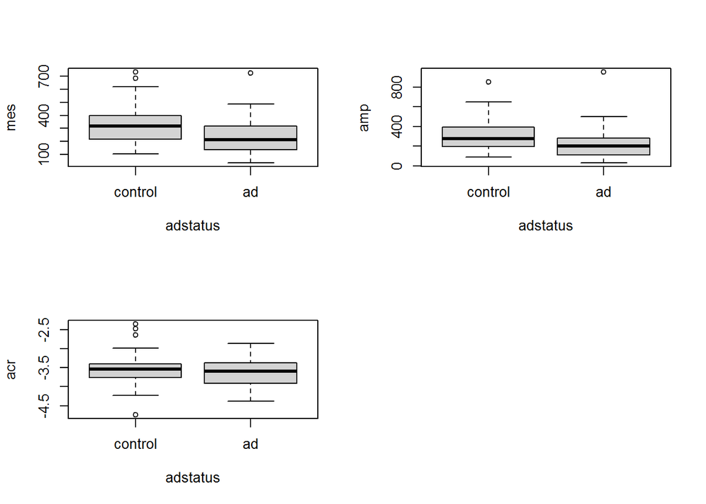

```r
path <- "E:/JHUPD/Deliverables/data/data"
setwd(path)
load("cogdfcosinor.RData") #pre-extracted cosinor analysis data
par(mfrow=c(2,2))
boxplot(mes~adstatus,data=dfcomb,names=c("control","ad"),ylab="mes")
boxplot(amp~adstatus,data=dfcomb,names=c("control","ad"),ylab="amp")
boxplot(acr~adstatus,data=dfcomb,names=c("control","ad"),ylab="acr")
```

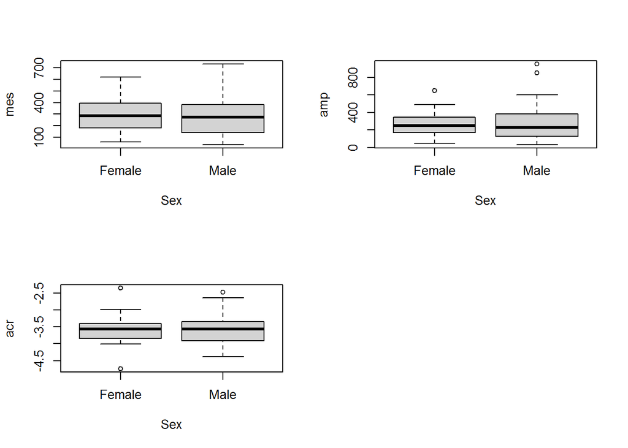

```r
par(mfrow=c(2,2))
boxplot(mes~Sex,data=dfcomb,names=c("Female","Male"),ylab="mes")
boxplot(amp~Sex,data=dfcomb,names=c("Female","Male"),ylab="amp")
boxplot(acr~Sex,data=dfcomb,names=c("Female","Male"),ylab="acr")
```

There seems to be some difference in the distribution of the mesor and amplitude parameter among the AD and CNC samples.

We display below the scatterplot of consior parameters with age, education and cognitive scores of attention, verbal memory and executive function.

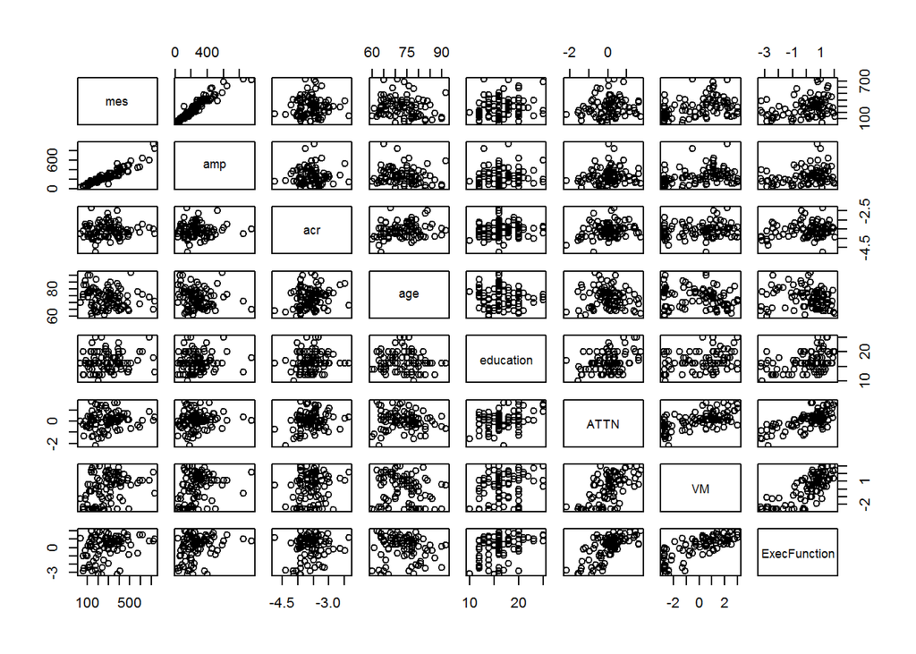

```r
subsetdfcomb<-dfcomb[,c(2,3,4,5,6,7,8,28,32,37)]
plot(subsetdfcomb[,-c(5,6)])
```

We study association between cognitive status (AD/CNC) with subject specific cosinor parameters using logistic regression model and adjusting for age,sex and education.

```r
library(dplyr)
library(knitr)
library(kableExtra)
library(readr)
library(tidyr)
library(sjPlot)

dfcomb$education[2]<-mean(dfcomb$education,na.rm=TRUE)
glm1<-glm(adstatus~age+sex+education,data=dfcomb,family = "binomial")
glm11<-glm(adstatus~age+sex+education+mes,data=dfcomb,family = "binomial")
glm12<-glm(adstatus~age+sex+education+amp,data=dfcomb,family = "binomial")
glm13<-glm(adstatus~age+sex+education+acr,data=dfcomb,family = "binomial")
tab_model(glm1,glm11,glm12,glm13,title = " Generalized Linear Model of adstatus on age, sex, education and cosinor parametrs")
```

Generalized Linear Model of adstatus on age, sex, education and cosinor parametrs

|  | adstatus |  |  | adstatus |  |  | adstatus |  |  | adstatus |  |  |
| --- | --- | --- | --- | --- | --- | --- | --- | --- | --- | --- | --- | --- |
| Predictors | Odds Ratios | CI | p | Odds Ratios | CI | p | Odds Ratios | CI | p | Odds Ratios | CI | p |
| (Intercept) | 62.64 | 0.21 – 25972.79 | 0.163 | 1723.97 | 2.38 – 2974925.39 | **0.035** | 957.78 | 1.60 – 1222361.50 | **0.045** | 6.19 | 0.00 – 32529.93 | 0.673 |
| age | 0.98 | 0.91 – 1.04 | 0.480 | 0.95 | 0.88 – 1.02 | 0.186 | 0.96 | 0.88 – 1.03 | 0.227 | 0.98 | 0.92 – 1.05 | 0.614 |
| sex | 7.10 | 2.72 – 20.36 | **<0.001** | 8.39 | 3.00 – 26.70 | **<0.001** | 9.05 | 3.24 – 28.78 | **<0.001** | 7.08 | 2.71 – 20.36 | **<0.001** |
| education | 0.80 | 0.66 – 0.93 | **0.008** | 0.80 | 0.66 – 0.95 | **0.014** | 0.80 | 0.66 – 0.94 | **0.011** | 0.81 | 0.67 – 0.94 | **0.012** |
| mes |  |  |  | 0.99 | 0.99 – 1.00 | **0.008** |  |  |  |  |  |  |
| amp |  |  |  |  |  |  | 1.00 | 0.99 – 1.00 | **0.011** |  |  |  |
| acr |  |  |  |  |  |  |  |  |  | 0.62 | 0.17 – 2.19 | 0.462 |
| Observations | 92 |  |  | 92 |  |  | 92 |  |  | 92 |  |  |
| R<sup>2</sup> Tjur | 0.248 |  |  | 0.310 |  |  | 0.314 |  |  | 0.252 |  |  |

The subject specific mesor and amplitude parameters are significant and higher values of these parameters seem to be associated lower risk of AD.

Next, we study association between cognitive scores and each of the subject specific cosinor parameters using linear regression model adjusting for age,sex and education.

```r
lm11<-lm(ATTN~age+sex+education,data=dfcomb)
lm12<-lm(ATTN~age+sex+education+mes,data=dfcomb)
lm13<-lm(ATTN~age+sex+education+amp,data=dfcomb)
lm14<-lm(ATTN~age+sex+education+acr,data=dfcomb)

tab_model(lm11,lm12,lm13,lm14,title = "Modelling cognitive scores of attention using cosinor parameters")
```

Modelling cognitive scores of attention using cosinor parameters

|  | ATTN |  |  | ATTN |  |  | ATTN |  |  | ATTN |  |  |
| --- | --- | --- | --- | --- | --- | --- | --- | --- | --- | --- | --- | --- |
| Predictors | Estimates | CI | p | Estimates | CI | p | Estimates | CI | p | Estimates | CI | p |
| (Intercept) | -1.20 | -2.99 – 0.60 | 0.188 | -1.42 | -3.27 – 0.42 | 0.129 | -1.42 | -3.26 – 0.41 | 0.127 | 0.56 | -1.97 – 3.09 | 0.663 |
| age | -0.00 | -0.02 – 0.02 | 0.988 | 0.00 | -0.02 – 0.02 | 0.886 | 0.00 | -0.02 – 0.02 | 0.882 | -0.00 | -0.03 – 0.02 | 0.675 |
| sex | -0.36 | -0.66 – -0.06 | **0.019** | -0.35 | -0.65 – -0.06 | **0.020** | -0.37 | -0.67 – -0.07 | **0.016** | -0.35 | -0.64 – -0.06 | **0.020** |
| education | 0.09 | 0.04 – 0.13 | **<0.001** | 0.08 | 0.04 – 0.13 | **0.001** | 0.08 | 0.04 – 0.13 | **<0.001** | 0.08 | 0.03 – 0.13 | **0.001** |
| mes |  |  |  | 0.00 | -0.00 – 0.00 | 0.309 |  |  |  |  |  |  |
| amp |  |  |  |  |  |  | 0.00 | -0.00 – 0.00 | 0.272 |  |  |  |
| acr |  |  |  |  |  |  |  |  |  | 0.38 | -0.01 – 0.77 | 0.058 |
| Observations | 92 |  |  | 92 |  |  | 92 |  |  | 92 |  |  |
| R<sup>2</sup> / R<sup>2</sup> adjusted | 0.189 / 0.161 |  |  | 0.199 / 0.162 |  |  | 0.200 / 0.163 |  |  | 0.222 / 0.186 |  |  |

```r
lm21<-lm(VM~age+sex+education,data=dfcomb)
lm22<-lm(VM~age+sex+education+mes,data=dfcomb)
lm23<-lm(VM~age+sex+education+amp,data=dfcomb)
lm24<-lm(VM~age+sex+education+acr,data=dfcomb)

tab_model(lm21,lm22,lm23,lm24,title = "Modelling cognitive scores of verbal memory using cosinor parameters")
```

Modelling cognitive scores of verbal memory using cosinor parameters

|  | VM |  |  | VM |  |  | VM |  |  | VM |  |  |
| --- | --- | --- | --- | --- | --- | --- | --- | --- | --- | --- | --- | --- |
| Predictors | Estimates | CI | p | Estimates | CI | p | Estimates | CI | p | Estimates | CI | p |
| (Intercept) | -0.80 | -4.76 – 3.16 | 0.690 | -2.32 | -6.19 – 1.56 | 0.238 | -2.25 | -6.09 – 1.60 | 0.249 | 3.07 | -2.52 – 8.67 | 0.278 |
| age | -0.02 | -0.07 – 0.03 | 0.389 | -0.01 | -0.05 – 0.04 | 0.693 | -0.01 | -0.05 – 0.04 | 0.684 | -0.03 | -0.08 – 0.02 | 0.209 |
| sex | -1.38 | -2.04 – -0.72 | **<0.001** | -1.36 | -1.98 – -0.73 | **<0.001** | -1.46 | -2.08 – -0.83 | **<0.001** | -1.36 | -2.01 – -0.71 | **<0.001** |
| education | 0.18 | 0.08 – 0.29 | **0.001** | 0.16 | 0.07 – 0.26 | **0.001** | 0.17 | 0.08 – 0.27 | **0.001** | 0.17 | 0.07 – 0.27 | **0.001** |
| mes |  |  |  | 0.00 | 0.00 – 0.01 | **0.002** |  |  |  |  |  |  |
| amp |  |  |  |  |  |  | 0.00 | 0.00 – 0.01 | **0.001** |  |  |  |
| acr |  |  |  |  |  |  |  |  |  | 0.83 | -0.03 – 1.69 | 0.058 |
| Observations | 92 |  |  | 92 |  |  | 92 |  |  | 92 |  |  |
| R<sup>2</sup> / R<sup>2</sup> adjusted | 0.282 / 0.258 |  |  | 0.360 / 0.331 |  |  | 0.365 / 0.336 |  |  | 0.311 / 0.280 |  |  |

```r
lm31<-lm(ExecFunction~age+sex+education,data=dfcomb)
lm32<-lm(ExecFunction~age+sex+education+mes,data=dfcomb)
lm33<-lm(ExecFunction~age+sex+education+amp,data=dfcomb)
lm34<-lm(ExecFunction~age+sex+education+acr,data=dfcomb)
tab_model(lm31,lm32,lm33,lm34,title = "Modelling cognitive scores of executive function using cosinor parameters")
```

Modelling cognitive scores of executive function using cosinor parameters

|  | ExecFunction |  |  | ExecFunction |  |  | ExecFunction |  |  | ExecFunction |  |  |
| --- | --- | --- | --- | --- | --- | --- | --- | --- | --- | --- | --- | --- |
| Predictors | Estimates | CI | p | Estimates | CI | p | Estimates | CI | p | Estimates | CI | p |
| (Intercept) | -1.40 | -4.40 – 1.61 | 0.359 | -2.47 | -5.43 – 0.50 | 0.102 | -2.39 | -5.34 – 0.56 | 0.111 | 0.94 | -3.34 – 5.22 | 0.664 |
| age | -0.01 | -0.04 – 0.03 | 0.643 | -0.00 | -0.03 – 0.03 | 0.989 | -0.00 | -0.03 – 0.03 | 0.972 | -0.01 | -0.05 – 0.02 | 0.439 |
| sex | -1.08 | -1.58 – -0.58 | **<0.001** | -1.07 | -1.54 – -0.59 | **<0.001** | -1.13 | -1.61 – -0.65 | **<0.001** | -1.07 | -1.57 – -0.57 | **<0.001** |
| education | 0.16 | 0.08 – 0.23 | **<0.001** | 0.14 | 0.07 – 0.22 | **<0.001** | 0.15 | 0.07 – 0.22 | **<0.001** | 0.15 | 0.07 – 0.23 | **<0.001** |
| mes |  |  |  | 0.00 | 0.00 – 0.00 | **0.003** |  |  |  |  |  |  |
| amp |  |  |  |  |  |  | 0.00 | 0.00 – 0.00 | **0.003** |  |  |  |
| acr |  |  |  |  |  |  |  |  |  | 0.50 | -0.16 – 1.16 | 0.134 |
| Observations | 92 |  |  | 92 |  |  | 92 |  |  | 92 |  |  |
| R<sup>2</sup> / R<sup>2</sup> adjusted | 0.300 / 0.276 |  |  | 0.366 / 0.337 |  |  | 0.366 / 0.337 |  |  | 0.318 / 0.287 |  |  |

**Takeaway** : The cosinor parameters mesor and amplitude are significantly associated with cognitive scores of VM (verbal memory) and ExecFunction (executive function) after adjusting for age, sex and education.

## 3.1 Summary

- The subject specific cosinor parameters mesor and amplitude are found to be discriminative of AD and CNC and associated with cognitive performance.
- Higher values of these parameters are found to be associated with lower odds of AD.

# 4 Nonparametric Analysis using Nonparametric Indices of Circadian Rhythmicity

We consider nonparametric analysis of actigraphy data using nonparametric indices of Circadian Rhythmicity. In Particular, we study association between the nonparametric indices of circadian rhythmicity with cognitive status and cognitive factor scores. The circadian indices IS (interdaily stability), IV (intradaily variability) and RA (relative amplitude) are again calculated using the “ActCR” package (code shown below) from minute level activity data.

```r
# library(ActCR)
# x is a activity vector
# raval = RA(x = x, method = "average")
# This extracts the circadian parameters.
```

we display boxplot of the subject specific nornparametric indices against adstatus and gender.

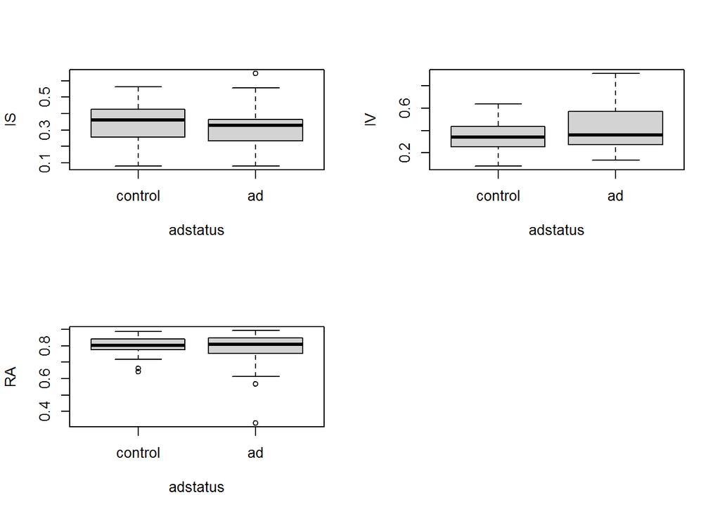

```r
path <- "E:/JHUPD/Deliverables/data/data"
setwd(path)
load("cogdfcirca.RData") #pre-extracted circadian analysis data
par(mfrow=c(2,2))
boxplot(is~adstatus,data=dfcomb,names=c("control","ad"),ylab="IS")
boxplot(iv~adstatus,data=dfcomb,names=c("control","ad"),ylab="IV")
boxplot(ra~adstatus,data=dfcomb,names=c("control","ad"),ylab="RA")

par(mfrow=c(2,2))
```

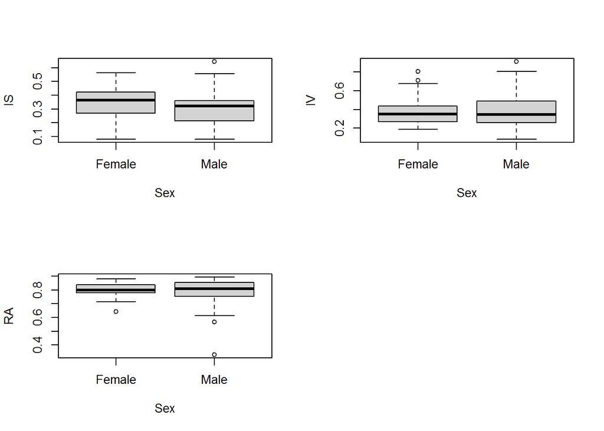

```r
boxplot(is~Sex,data=dfcomb,names=c("Female","Male"),ylab="IS")
boxplot(iv~Sex,data=dfcomb,names=c("Female","Male"),ylab="IV")
boxplot(ra~Sex,data=dfcomb,names=c("Female","Male"),ylab="RA")
```

It is not immediately clear which indices could be informative for cognitive performance. We display below the scatterplot of the nonparametric indices with age, education and cognitive scores of attention, verbal memory and executive function.

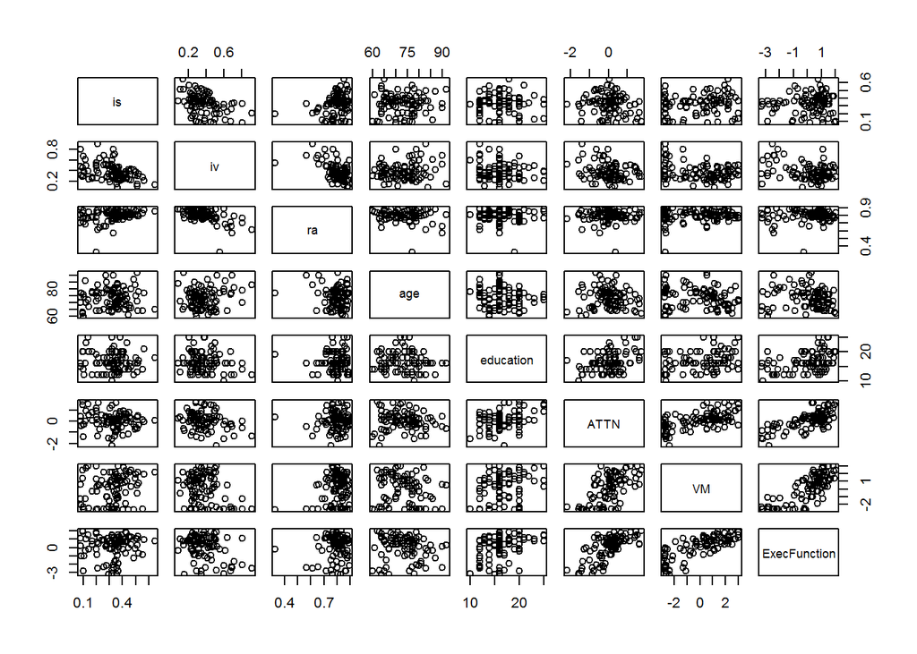

```r
subsetdfcomb<-dfcomb[,c(2,3,4,5,6,7,8,28,32,37)]
plot(subsetdfcomb[,-c(5,6)])
```

Next, we study association between cognitive staus (AD/CNC) with subject specific nonparametric indices of circadian rhythmicity using logistic regression model adjusting for age,sex and education.

```r
dfcomb$education[2]<-mean(dfcomb$education,na.rm=TRUE)
glm1<-glm(adstatus~age+sex+education,data=dfcomb,family = "binomial")
glm11<-glm(adstatus~age+sex+education+is,data=dfcomb,family = "binomial")
glm12<-glm(adstatus~age+sex+education+iv,data=dfcomb,family = "binomial")
glm13<-glm(adstatus~age+sex+education+ra,data=dfcomb,family = "binomial")
tab_model(glm1,glm11,glm12,glm13,title = "Modelling cognitive status using circadian rhythmicity parameters")
```

Modelling cognitive status using circadian rhythmicity parameters

|  | adstatus |  |  | adstatus |  |  | adstatus |  |  | adstatus |  |  |
| --- | --- | --- | --- | --- | --- | --- | --- | --- | --- | --- | --- | --- |
| Predictors | Odds Ratios | CI | p | Odds Ratios | CI | p | Odds Ratios | CI | p | Odds Ratios | CI | p |
| (Intercept) | 62.64 | 0.21 – 25972.79 | 0.163 | 144.77 | 0.37 – 85350.88 | 0.111 | 18.51 | 0.05 – 9439.87 | 0.345 | 570.67 | 0.25 – 2398136.72 | 0.117 |
| age | 0.98 | 0.91 – 1.04 | 0.480 | 0.98 | 0.91 – 1.04 | 0.485 | 0.97 | 0.90 – 1.04 | 0.342 | 0.97 | 0.91 – 1.04 | 0.429 |
| sex | 7.10 | 2.72 – 20.36 | **<0.001** | 6.71 | 2.55 – 19.31 | **<0.001** | 8.12 | 2.97 – 24.95 | **<0.001** | 6.90 | 2.64 – 19.80 | **<0.001** |
| education | 0.80 | 0.66 – 0.93 | **0.008** | 0.79 | 0.66 – 0.93 | **0.007** | 0.82 | 0.68 – 0.96 | **0.021** | 0.80 | 0.66 – 0.93 | **0.009** |
| is |  |  |  | 0.11 | 0.00 – 5.90 | 0.282 |  |  |  |  |  |  |
| iv |  |  |  |  |  |  | 58.49 | 2.26 – 2227.83 | **0.019** |  |  |  |
| ra |  |  |  |  |  |  |  |  |  | 0.09 | 0.00 – 27.10 | 0.424 |
| Observations | 92 |  |  | 92 |  |  | 92 |  |  | 92 |  |  |
| R<sup>2</sup> Tjur | 0.248 |  |  | 0.253 |  |  | 0.303 |  |  | 0.253 |  |  |

Among the nonparametric indices only IV is found to have significant association with AD, in particular higher IV is found to associated with higher risk of AD which is interesting from a physiological perspective.

Next, we study association between cognitive factor scores with the subject specific nonparametric indices adjusting for age,sex and education.

```r
lm11<-lm(ATTN~age+sex+education,data=dfcomb)
lm12<-lm(ATTN~age+sex+education+is,data=dfcomb)
lm13<-lm(ATTN~age+sex+education+iv,data=dfcomb)
lm14<-lm(ATTN~age+sex+education+ra,data=dfcomb)
tab_model(lm11,lm12,lm13,lm14,title = "Modelling cognitive scores of attention using circadian parameters")
```

Modelling cognitive scores of attention using circadian parameters

|  | ATTN |  |  | ATTN |  |  | ATTN |  |  | ATTN |  |  |
| --- | --- | --- | --- | --- | --- | --- | --- | --- | --- | --- | --- | --- |
| Predictors | Estimates | CI | p | Estimates | CI | p | Estimates | CI | p | Estimates | CI | p |
| (Intercept) | -1.20 | -2.99 – 0.60 | 0.188 | -0.87 | -2.69 – 0.96 | 0.348 | -0.91 | -2.70 – 0.88 | 0.315 | -1.38 | -3.84 – 1.09 | 0.271 |
| age | -0.00 | -0.02 – 0.02 | 0.988 | 0.00 | -0.02 – 0.02 | 0.959 | 0.00 | -0.02 – 0.02 | 0.833 | 0.00 | -0.02 – 0.02 | 0.992 |
| sex | -0.36 | -0.66 – -0.06 | **0.019** | -0.39 | -0.69 – -0.09 | **0.011** | -0.36 | -0.65 – -0.06 | **0.018** | -0.35 | -0.66 – -0.05 | **0.021** |
| education | 0.09 | 0.04 – 0.13 | **<0.001** | 0.08 | 0.04 – 0.13 | **0.001** | 0.08 | 0.03 – 0.12 | **0.001** | 0.09 | 0.04 – 0.13 | **<0.001** |
| is |  |  |  | -0.96 | -2.15 – 0.22 | 0.110 |  |  |  |  |  |  |
| iv |  |  |  |  |  |  | -0.90 | -1.83 – 0.03 | 0.059 |  |  |  |
| ra |  |  |  |  |  |  |  |  |  | 0.20 | -1.67 – 2.07 | 0.833 |
| Observations | 92 |  |  | 92 |  |  | 92 |  |  | 92 |  |  |
| R<sup>2</sup> / R<sup>2</sup> adjusted | 0.189 / 0.161 |  |  | 0.213 / 0.176 |  |  | 0.222 / 0.186 |  |  | 0.189 / 0.152 |  |  |

```r
lm21<-lm(VM~age+sex+education,data=dfcomb)
lm22<-lm(VM~age+sex+education+is,data=dfcomb)
lm23<-lm(VM~age+sex+education+iv,data=dfcomb)
lm24<-lm(VM~age+sex+education+ra,data=dfcomb)
tab_model(lm21,lm22,lm23,lm24,title = "Modelling cognitive scores of verbal memory using circadian parameters")
```

Modelling cognitive scores of verbal memory using circadian parameters

|  | VM |  |  | VM |  |  | VM |  |  | VM |  |  |
| --- | --- | --- | --- | --- | --- | --- | --- | --- | --- | --- | --- | --- |
| Predictors | Estimates | CI | p | Estimates | CI | p | Estimates | CI | p | Estimates | CI | p |
| (Intercept) | -0.80 | -4.76 – 3.16 | 0.690 | -1.75 | -5.74 – 2.23 | 0.384 | 0.09 | -3.78 – 3.97 | 0.963 | -4.10 | -9.47 – 1.26 | 0.132 |
| age | -0.02 | -0.07 – 0.03 | 0.389 | -0.02 | -0.07 – 0.02 | 0.335 | -0.01 | -0.06 – 0.03 | 0.573 | -0.02 | -0.06 – 0.03 | 0.507 |
| sex | -1.38 | -2.04 – -0.72 | **<0.001** | -1.29 | -1.94 – -0.63 | **<0.001** | -1.38 | -2.01 – -0.74 | **<0.001** | -1.33 | -1.98 – -0.68 | **<0.001** |
| education | 0.18 | 0.08 – 0.29 | **0.001** | 0.19 | 0.09 – 0.29 | **<0.001** | 0.16 | 0.06 – 0.26 | **0.002** | 0.18 | 0.08 – 0.28 | **<0.001** |
| is |  |  |  | 2.78 | 0.19 – 5.37 | **0.036** |  |  |  |  |  |  |
| iv |  |  |  |  |  |  | -2.79 | -4.81 – -0.78 | **0.007** |  |  |  |
| ra |  |  |  |  |  |  |  |  |  | 3.67 | -0.40 – 7.73 | 0.076 |
| Observations | 92 |  |  | 92 |  |  | 92 |  |  | 92 |  |  |
| R<sup>2</sup> / R<sup>2</sup> adjusted | 0.282 / 0.258 |  |  | 0.318 / 0.286 |  |  | 0.340 / 0.309 |  |  | 0.308 / 0.276 |  |  |

```r
lm31<-lm(ExecFunction~age+sex+education,data=dfcomb)
lm32<-lm(ExecFunction~age+sex+education+is,data=dfcomb)
lm33<-lm(ExecFunction~age+sex+education+iv,data=dfcomb)
lm34<-lm(ExecFunction~age+sex+education+ra,data=dfcomb)
tab_model(lm31,lm32,lm33,lm34,title = "Modelling cognitive scores of ececutive function using circadian parameters")
```

Modelling cognitive scores of ececutive function using circadian parameters

|  | ExecFunction |  |  | ExecFunction |  |  | ExecFunction |  |  | ExecFunction |  |  |
| --- | --- | --- | --- | --- | --- | --- | --- | --- | --- | --- | --- | --- |
| Predictors | Estimates | CI | p | Estimates | CI | p | Estimates | CI | p | Estimates | CI | p |
| (Intercept) | -1.40 | -4.40 – 1.61 | 0.359 | -1.75 | -4.84 – 1.34 | 0.263 | -0.71 | -3.65 – 2.23 | 0.632 | -2.18 | -6.32 – 1.96 | 0.299 |
| age | -0.01 | -0.04 – 0.03 | 0.643 | -0.01 | -0.04 – 0.03 | 0.614 | -0.00 | -0.04 – 0.03 | 0.882 | -0.01 | -0.04 – 0.03 | 0.692 |
| sex | -1.08 | -1.58 – -0.58 | **<0.001** | -1.05 | -1.55 – -0.54 | **<0.001** | -1.08 | -1.56 – -0.60 | **<0.001** | -1.07 | -1.57 – -0.56 | **<0.001** |
| education | 0.16 | 0.08 – 0.23 | **<0.001** | 0.16 | 0.08 – 0.24 | **<0.001** | 0.14 | 0.06 – 0.21 | **<0.001** | 0.16 | 0.08 – 0.23 | **<0.001** |
| is |  |  |  | 1.03 | -0.98 – 3.04 | 0.310 |  |  |  |  |  |  |
| iv |  |  |  |  |  |  | -2.15 | -3.68 – -0.62 | **0.006** |  |  |  |
| ra |  |  |  |  |  |  |  |  |  | 0.87 | -2.27 – 4.00 | 0.584 |
| Observations | 92 |  |  | 92 |  |  | 92 |  |  | 92 |  |  |
| R<sup>2</sup> / R<sup>2</sup> adjusted | 0.300 / 0.276 |  |  | 0.308 / 0.276 |  |  | 0.358 / 0.328 |  |  | 0.302 / 0.270 |  |  |

**Takeaway** : IV (intradaily variability), a nonparametric metric representing fragmentation of circadian rhtymicity seems to be most informative for cognitive scores.

## 4.1 Summary

- The subject specific circadian indices of IV is found to be discriminative of AD and CNC and associated with cognitive performance.
- Higher values of IV is found to be associated with higher odds of AD.

# 5 FOSR Analysis Using Diurnal Mean Activity

We consider functional approaches for modelling continuous 24*7 actigraphy data. For each subject we derive the mean daily activity curve $X_i(t)$ averaged over 7 days. The smoothed average activity profiles for AD and cognitively normal control (CNC) samples are displayed below.

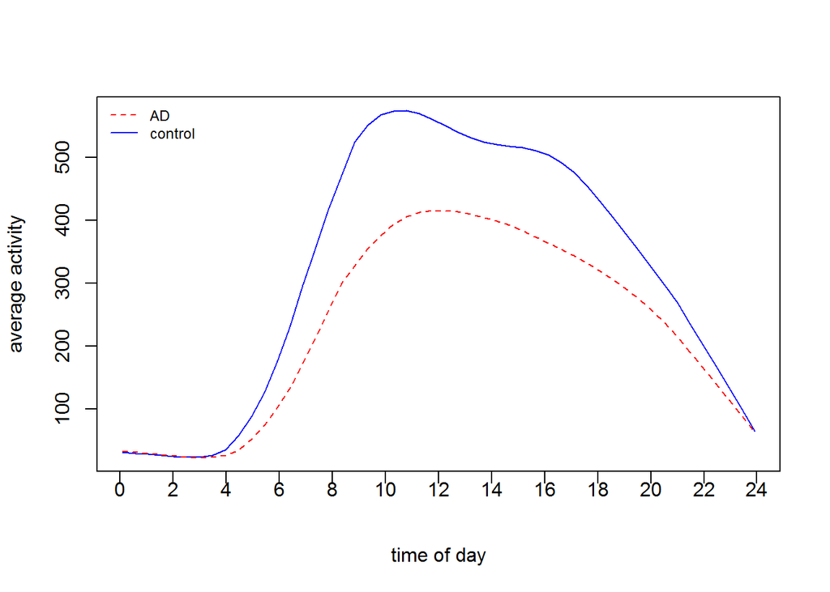

```r
load("actminutelevel_144.RData") #pre-extracted diurnal analysis (mean) data
subjdf$education[2]<-mean(subjdf$education,na.rm=TRUE)
tbtick<-seq(0,1440,by=10)
binmid<-tbtick+5
binmid<-binmid[-145]
indAD<-which(subjdf$adstatus==1)
actad<-subjdf$actmat[indAD,]
actcontrol<-subjdf$actmat[-indAD,]
cnavg<-colMeans(actcontrol)
adavg<-colMeans(actad)
l1<-loess.smooth(binmid, cnavg,span = 0.25)
l2<-loess.smooth(binmid, adavg,span = 0.25)
plot(l1$x/60,l1$y,type="l",col="blue",xaxt="n",xlab="time of day",ylab="average activity")
xtick<-seq(0, 24, by=2)
axis(side=1, at=xtick, labels = FALSE)
text(x=xtick,  par("usr")[3],
     labels = xtick, srt = 0, pos = 1, xpd = TRUE)
lines(l2$x/60,l2$y,type="l",col="red",lty=2)
legend('topleft',c("AD ","control") ,
       lty=c(2,1), col=c("red", "blue"), bty='n', cex=.75)
```

The AD samples have distinctly lower activity levels during morning (10 a.m) to late afternoon (4-5 p.m). We fit a function-on-scalar regression (FOSR) model analyzing dependence of diurnal mean activity on adstatus (AD/CNC) and adjusting for age, sex and education. We use the pffr function in “refund” package for implementation of FOSR.

```r
library(refund)
fit <- pffr(actmat~ age+Sex+adstatus+education,yind=(binmid/60), data = subjdf,bs.yindex = list(bs = "ps",
k = 12, m = c(2, 2)), bs.int = list(bs = "ps", k = 12, m = c(2, 2)))
summary(fit)
```

```
##
## Family: gaussian
## Link function: identity
##
## Formula:
## actmat ~ age + Sex + adstatus + education
##
## Constant coefficients:
##             Estimate Std. Error t value Pr(>|t|)
## (Intercept)   564.49      30.33   18.61   <2e-16 ***
## ---
## Signif. codes:  0 '***' 0.001 '**' 0.01 '*' 0.05 '.' 0.1 ' ' 1
##
## Smooth terms & functional coefficients:
##                     edf Ref.df      F p-value
## Intercept(yindex) 7.328  8.102 30.102  <2e-16 ***
## age(yindex)       9.448 10.097 25.399  <2e-16 ***
## Sex(yindex)       6.604  7.607 13.735  <2e-16 ***
## adstatus(yindex)  8.518  9.491 53.848  <2e-16 ***
## education(yindex) 2.931  3.387  2.081   0.118
## ---
## Signif. codes:  0 '***' 0.001 '**' 0.01 '*' 0.05 '.' 0.1 ' ' 1
##
## R-sq.(adj) =  0.343   Deviance explained = 34.5%
## -REML score =  93413  Scale est. = 77725     n = 13248 (92 x 144)
```

We notice the effect of adstatus to be significant implying significant difference in diurnal mean activity betweeen AD and CNC samples. The estimated time-varying effect of the predictors are displayed below.

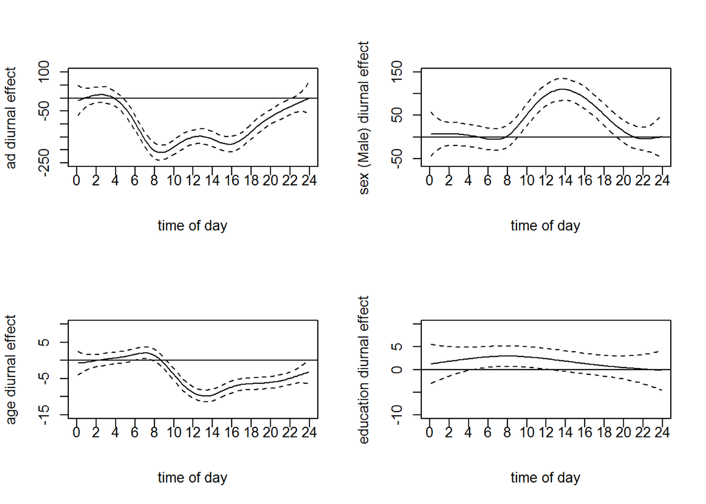

**FOSR Model Results**

The estimated coefficient function for adstatus show significantly lower activity levels for AD samples during the day between 8 a.m to 4 p.m. The magnitude of the difference is particularly pronouncd in the morning (8-10 a.m) and afternoon (4 p.m). The estimated coefficient function for sex (male) is significant and positive between 10 a.m to 6 p.m indicating males have higher levels of physical activity during this window. The estimated coefficient function for age is negative 10 a.m onwards indicating drop in levels of physical activity in this window with increasing age. The effect of education is not found to be significant.

We display the fitted diurnal profiles of expected physical activity at mean level of age, education, where analogous activity patterns for AD/control subjects can be observed.

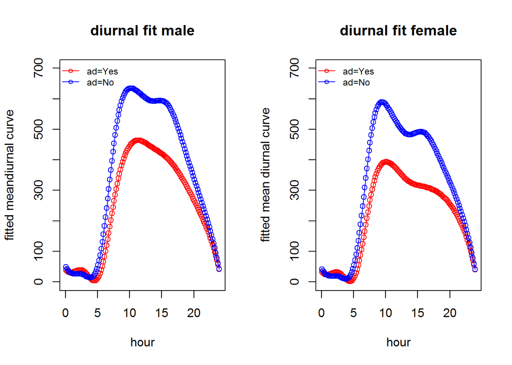

## 5.1 Summary

- AD samples are found to have distinctly lower levels of diurnal mean activity compared to cognitively normal controls.
- Males are found to have significantly high daily mean activity during 10 a.m to 6 p.m.
- With higher age there is a significant drop in diurnal levels of mean physical activity.

# 6 SOFR Analysis of Cognitive Scores Using Diurnal Mean Activity:

Next, we perform SOFR (scalar-on-function regression), modelling continuous congnitive scores as a function of diurnal physical activity and adjusting for age, sex and education. The associated coeffcient functions corresponding to diurnal mean activity are also displayed which represent the effect of diurnal mean activity on the cognitive scores. We use the pfr function in “refund” package for implementation of SOFR.

```
##
## Family: gaussian
## Link function: identity
##
## Formula:
## ATTN ~ age + Sex + education + s(x = actmat.tmat, by = L.actmat,
##     k = 12, bs = "ps", m = 2)
##
## Parametric coefficients:
##              Estimate Std. Error t value Pr(>|t|)
## (Intercept) -1.157410   0.959899  -1.206 0.231221
## age         -0.001382   0.011111  -0.124 0.901270
## Sex         -0.349349   0.150100  -2.327 0.022294 *
## education    0.080485   0.023370   3.444 0.000889 ***
## ---
## Signif. codes:  0 '***' 0.001 '**' 0.01 '*' 0.05 '.' 0.1 ' ' 1
##
## Approximate significance of smooth terms:
##                           edf Ref.df     F p-value
## s(actmat.tmat):L.actmat 2.124  2.237 1.047   0.413
##
## R-sq.(adj) =  0.163   Deviance explained =   21%
## -REML = 120.84  Scale est. = 0.50234   n = 92
```

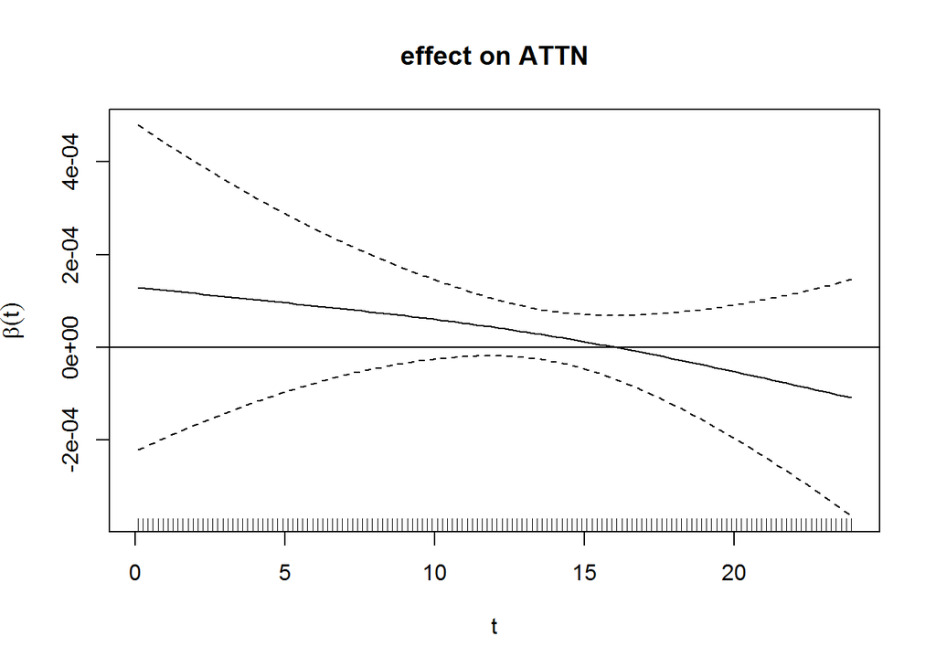

```
##
## Family: gaussian
## Link function: identity
##
## Formula:
## VM ~ age + Sex + education + s(x = actmat.tmat, by = L.actmat,
##     k = 12, bs = "ps", m = 2)
##
## Parametric coefficients:
##             Estimate Std. Error t value Pr(>|t|)
## (Intercept) -1.56118    2.00629  -0.778   0.4386
## age         -0.01731    0.02323  -0.745   0.4581
## Sex         -1.33814    0.31346  -4.269 5.04e-05 ***
## education    0.15653    0.04885   3.204   0.0019 **
## ---
## Signif. codes:  0 '***' 0.001 '**' 0.01 '*' 0.05 '.' 0.1 ' ' 1
##
## Approximate significance of smooth terms:
##                         edf Ref.df     F p-value
## s(actmat.tmat):L.actmat   2      2 6.301 0.00276 **
## ---
## Signif. codes:  0 '***' 0.001 '**' 0.01 '*' 0.05 '.' 0.1 ' ' 1
##
## R-sq.(adj) =  0.338   Deviance explained = 37.4%
## -REML = 184.21  Scale est. = 2.1962    n = 92
```

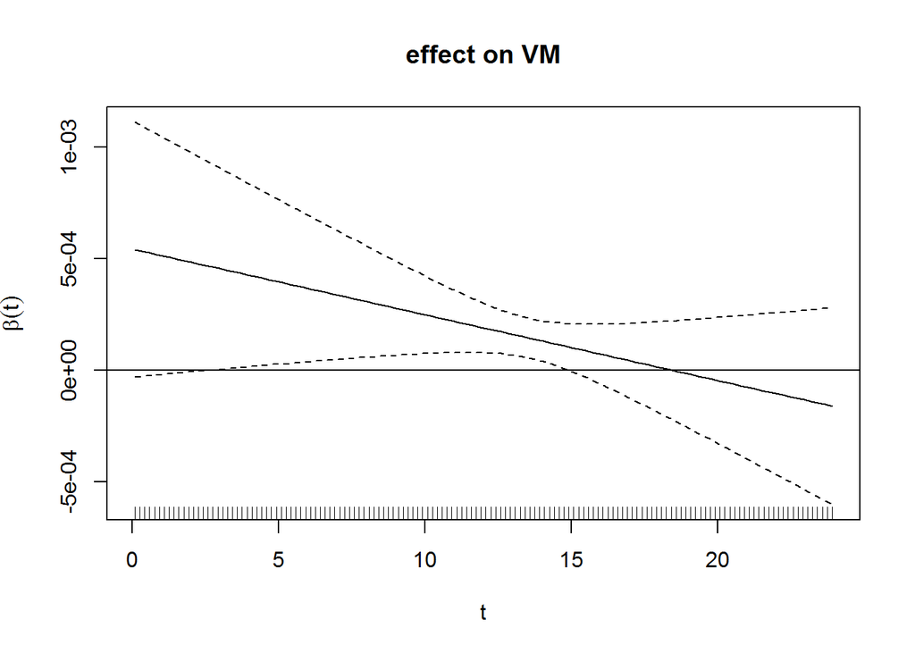

```
##
## Family: gaussian
## Link function: identity
##
## Formula:
## ExecFunction ~ age + Sex + education + s(x = actmat.tmat, by = L.actmat,
##     k = 12, bs = "ps", m = 2)
##
## Parametric coefficients:
##              Estimate Std. Error t value Pr(>|t|)
## (Intercept) -1.943691   1.539016  -1.263 0.210023
## age         -0.006036   0.017818  -0.339 0.735597
## Sex         -1.051272   0.240455  -4.372 3.43e-05 ***
## education    0.136299   0.037472   3.637 0.000469 ***
## ---
## Signif. codes:  0 '***' 0.001 '**' 0.01 '*' 0.05 '.' 0.1 ' ' 1
##
## Approximate significance of smooth terms:
##                         edf Ref.df     F p-value
## s(actmat.tmat):L.actmat   2  2.001 5.319 0.00659 **
## ---
## Signif. codes:  0 '***' 0.001 '**' 0.01 '*' 0.05 '.' 0.1 ' ' 1
##
## R-sq.(adj) =  0.341   Deviance explained = 37.7%
## -REML = 161.41  Scale est. = 1.2923    n = 92
```

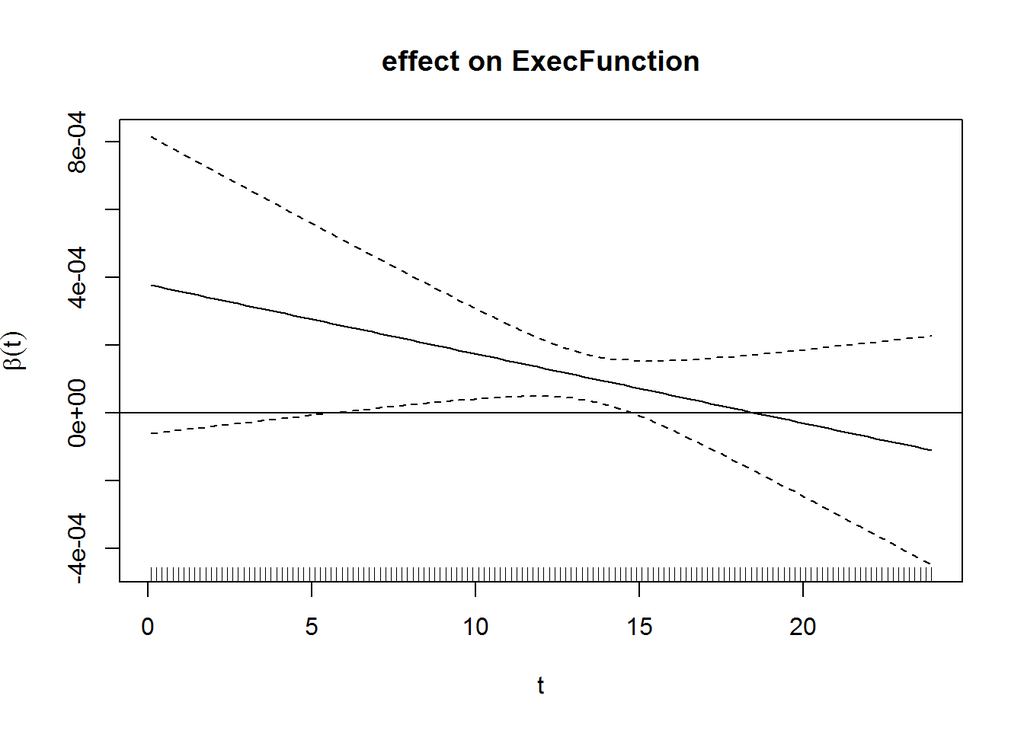

## 6.1 Summary

- The linear functional effect of diurnal mean activity is significant for the cognitive scores of VM and EF but not for ATTN.
- The plots of the estimated coefficient functions reveal the window 8 a.m to 3 p.m to have a significant positive effect on the cognitive scores, indicating high activity in this window leads to higher cognitive scores and hence lower possibility of dementia.

# 7 FOSR Analysis Using Diurnal SD Activity Curves

So far we have used the mean levels of daily activity as outcome or predictor in our analysis to explore its association with cognitive performance. The variability of the curves could also potentially provide uniqe insight into cognitive impairment. For this purpose we obtain the diurnal SD (standard deviation) curve $S_i(t)$ as follows. For raw activity data $X_{ij}(s)$, $j=1,\ldots,7$ we define $S_i(t)=sd\{X_{ij}(s)\}, s \in (t-h,t+h)$, where $2*h$ is the window length and taken to be 10 minutes in this analysis. The smoothed SD_activity profiles for AD and CNC averaged across the respective samples are displayed below.

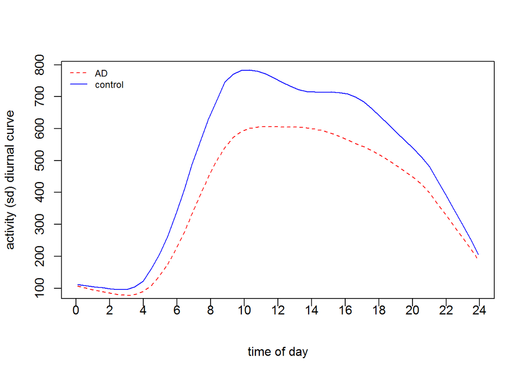

The AD samples have distinctly lower variability for activity levels during morning (8 a.m) to late evening (5 p.m). We again fit a FOSR model analyzing the effect of adstatus on diurnal pattern of SD_activity adjusting for age,sex and education.

```r
library(refund)
fit <- pffr(actmat~ age+Sex+adstatus+education,yind=(binmid/60), data = subjdf,bs.yindex = list(bs = "ps",
k = 12, m = c(2, 2)), bs.int = list(bs = "ps", k = 12, m = c(2, 2)))
summary(fit)
```

```
##
## Family: gaussian
## Link function: identity
##
## Formula:
## actmat ~ age + Sex + adstatus + education
##
## Constant coefficients:
##             Estimate Std. Error t value Pr(>|t|)
## (Intercept)   871.60      32.28      27   <2e-16 ***
## ---
## Signif. codes:  0 '***' 0.001 '**' 0.01 '*' 0.05 '.' 0.1 ' ' 1
##
## Smooth terms & functional coefficients:
##                     edf Ref.df      F p-value
## Intercept(yindex) 7.174  7.934 33.180 < 2e-16 ***
## age(yindex)       8.945  9.659 47.200 < 2e-16 ***
## Sex(yindex)       5.499  6.395 30.169 < 2e-16 ***
## adstatus(yindex)  8.233  9.237 63.551 < 2e-16 ***
## education(yindex) 5.097  5.918  7.655 4.8e-08 ***
## ---
## Signif. codes:  0 '***' 0.001 '**' 0.01 '*' 0.05 '.' 0.1 ' ' 1
##
## R-sq.(adj) =  0.426   Deviance explained = 42.8%
## -REML score =  94236  Scale est. = 88052     n = 13248 (92 x 144)
```

**FOSR Results Using SD Activity**

We notice the effect of adstatus to be again significant implying significant difference in diurnal SD activity betweeen AD and CNC samples. The estimated time-varying effect of the predictors are displayed below.

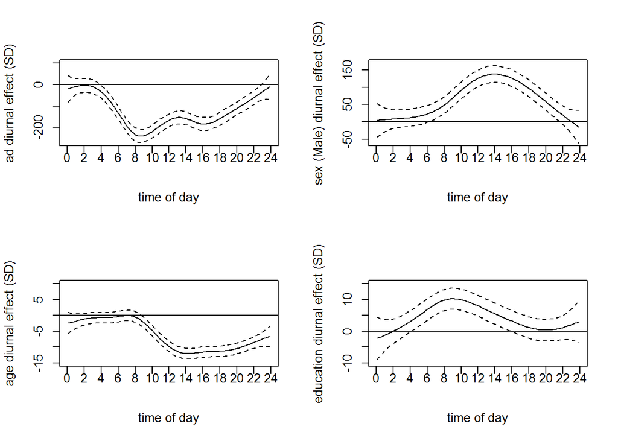

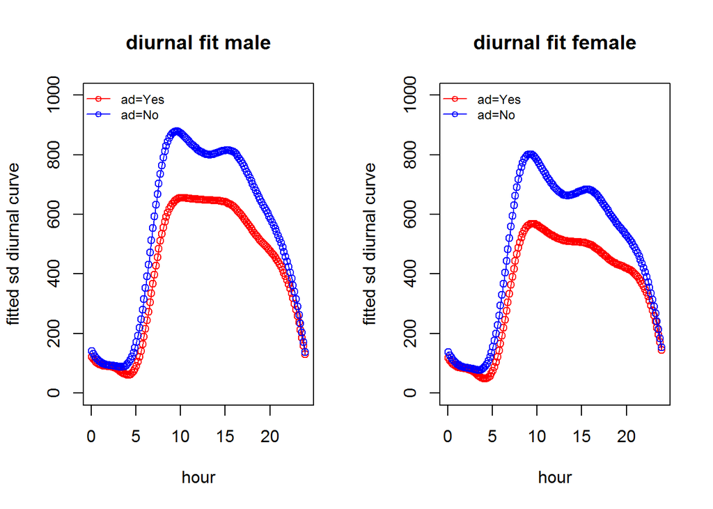

## 7.1 Summary

AD samples are found to have significantly lower levels of diurnal SD activity from 8 a.m to 5 p.m compared to cognitively normal controls.

# 8 SOFR Analysis Using SD_Activity Curve

Next, we perform SOFR modeling of the congnitive scores as function of diurnal SD_activity, adjusting for age, sex and education. The results from the model fit and the estimated coefficient functions are displayed below.

```
##
## Family: gaussian
## Link function: identity
##
## Formula:
## ATTN ~ age + Sex + education + s(x = actmat.tmat, by = L.actmat,
##     k = 12, bs = "ps", m = 2)
##
## Parametric coefficients:
##              Estimate Std. Error t value Pr(>|t|)
## (Intercept) -1.833696   0.994330  -1.844  0.06860 .
## age          0.004232   0.011193   0.378  0.70628
## Sex         -0.364125   0.146362  -2.488  0.01478 *
## education    0.072112   0.023069   3.126  0.00242 **
## ---
## Signif. codes:  0 '***' 0.001 '**' 0.01 '*' 0.05 '.' 0.1 ' ' 1
##
## Approximate significance of smooth terms:
##                         edf Ref.df   F p-value
## s(actmat.tmat):L.actmat   2      2 3.4  0.0378 *
## ---
## Signif. codes:  0 '***' 0.001 '**' 0.01 '*' 0.05 '.' 0.1 ' ' 1
##
## R-sq.(adj) =  0.205   Deviance explained = 24.8%
## -REML = 118.82  Scale est. = 0.47749   n = 92
```

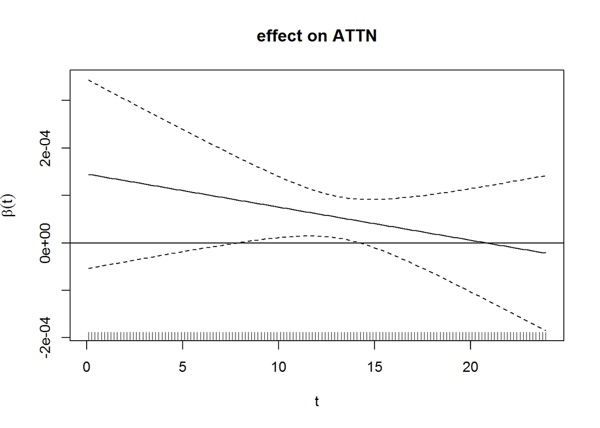

```
##
## Family: gaussian
## Link function: identity
##
## Formula:
## VM ~ age + Sex + education + s(x = actmat.tmat, by = L.actmat,
##     k = 12, bs = "ps", m = 2)
##
## Parametric coefficients:
##               Estimate Std. Error t value Pr(>|t|)
## (Intercept) -3.5390186  2.0920991  -1.692  0.09434 .
## age          0.0005463  0.0235506   0.023  0.98155
## Sex         -1.4193152  0.3079485  -4.609  1.4e-05 ***
## education    0.1405125  0.0485366   2.895  0.00481 **
## ---
## Signif. codes:  0 '***' 0.001 '**' 0.01 '*' 0.05 '.' 0.1 ' ' 1
##
## Approximate significance of smooth terms:
##                           edf Ref.df     F  p-value
## s(actmat.tmat):L.actmat 2.001  2.002 8.218 0.000529 ***
## ---
## Signif. codes:  0 '***' 0.001 '**' 0.01 '*' 0.05 '.' 0.1 ' ' 1
##
## R-sq.(adj) =  0.362   Deviance explained = 39.7%
## -REML = 182.79  Scale est. = 2.1138    n = 92
```

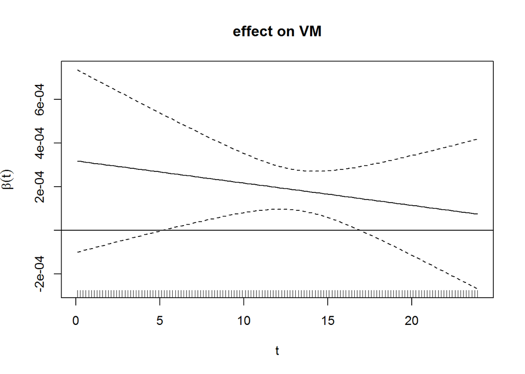

```
##
## Family: gaussian
## Link function: identity
##
## Formula:
## ExecFunction ~ age + Sex + education + s(x = actmat.tmat, by = L.actmat,
##     k = 12, bs = "ps", m = 2)
##
## Parametric coefficients:
##              Estimate Std. Error t value Pr(>|t|)
## (Intercept) -3.321052   1.595475  -2.082  0.04036 *
## age          0.006119   0.017960   0.341  0.73414
## Sex         -1.106491   0.234849  -4.711 9.37e-06 ***
## education    0.122976   0.037015   3.322  0.00131 **
## ---
## Signif. codes:  0 '***' 0.001 '**' 0.01 '*' 0.05 '.' 0.1 ' ' 1
##
## Approximate significance of smooth terms:
##                         edf Ref.df     F p-value
## s(actmat.tmat):L.actmat   2      2 7.793 0.00076 ***
## ---
## Signif. codes:  0 '***' 0.001 '**' 0.01 '*' 0.05 '.' 0.1 ' ' 1
##
## R-sq.(adj) =  0.373   Deviance explained = 40.7%
## -REML = 159.48  Scale est. = 1.2294    n = 92
```

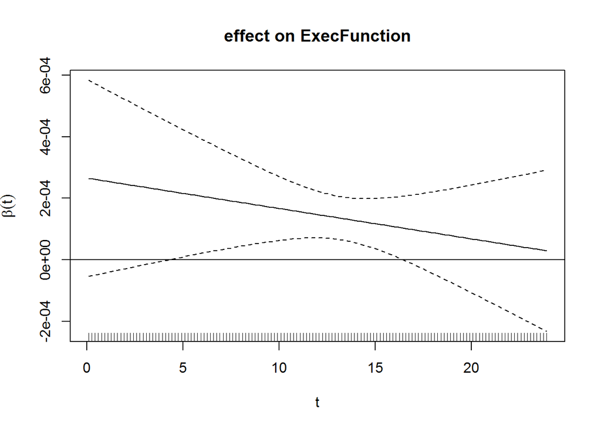

## 8.1 Summary

- We see that the sd_activity profiles explains a slightly higher percentage of variation in terms of adjusted $R^2$ for the cognitive scores and are signficant.
- The plot of the coefficient functions again reveal the window 8 a.m to 3 p.m to be significant.

**Remark:** We also used diurnal quantile activity profiles (95th perrcentile) which showed similar patterns and predictive performance in both FOSR and SOFR modelling as SD_activity.

# 9 Modelling Using Subject Specific Quantile Functions of Activity

## 9.1 SOFR analysis Using Subject Specific Quantile Functions

Distributional regression is an emerging area of research which have diverse applications specially for multi-view and repeated measures data. Various ways to incorporate the distributional information could involve the distribution function itself, density function, histogram, quantile function etc. Although they all essentially characterize the underlying distribution, they answer different questions from practical point of view. The subject specific quantile functions enjoy uniform support on $(0,1)$ unlike subject specific histograms or distribution functions which can possibly have unequal (effective) support. In this section, We consider using the subject specific quantile functions $Q_i(p)$ of physical activity for SOFR modelling of cognitive status and cognitive scores. First, we display the quantile functions of the AD group and CNC groups averaged over the respective samples.

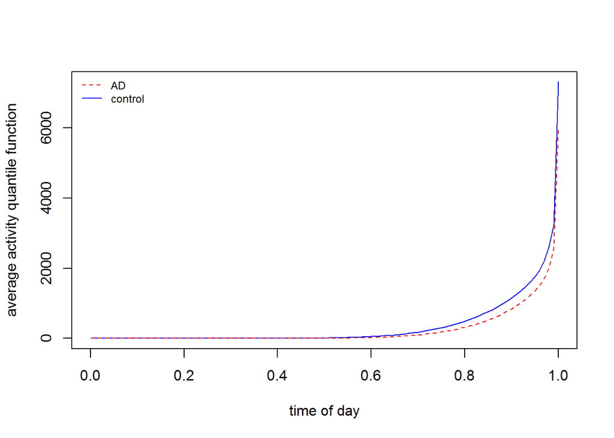

```r
load("actminutelevel_qf.RData") #pre-extracted subject-specific quantile functions #summary(subjdf)
subjdf$education[2]<-mean(subjdf$education,na.rm=TRUE)
p<-seq(0,1,l=101)
indAD<-which(subjdf$adstatus==1)
actad<-subjdf$actmat[indAD,]
actcontrol<-subjdf$actmat[-indAD,]
cnavg<-colMeans(actcontrol)
adavg<-colMeans(actad)
l1<-loess.smooth(p, cnavg,span = 0.5)
l2<-loess.smooth(p, adavg,span=0.5)
#plot raw average quantile function or smoothed
plot(p,cnavg,type="l",col="blue",xlab="time of day",ylab="average activity quantile function")
#xtick<-seq(0, 24, by=2)
#axis(side=1, at=xtick, labels = FALSE)
#text(x=xtick,  par("usr")[3],
 #    labels = xtick, srt = 0, pos = 1, xpd = TRUE)
lines(p,adavg,type="l",col="red",lty=2)
legend('topleft',c("AD ","control") ,
       lty=c(2,1), col=c("red", "blue"), bty='n', cex=.75)
```

The AD samples have distinctly lower levels of maximal physical activity compared to the CNC group. We fit a SOFR model using the logit link function, modelling cognitive status (AD/CNC) using $Q_i(p)$ and adjusting for age,sex and education. The results from the fit and estimated functional effect $\beta(p)$ are shown below.

```r
load("actminutelevel_qf.RData") #pre-extracted quantile functions
#summary(subjdf)
subjdf$education[2]<-mean(subjdf$education,na.rm=TRUE)
library(refund)
p<-seq(0,1,l=101)
fit.lf <- pfr(adstatus~ age+Sex+education+lf(actmat,argvals=p, k=12, bs="ps",m=2),data = subjdf,family="binomial")
summary(fit.lf)
```

```
##
## Family: binomial
## Link function: logit
##
## Formula:
## adstatus ~ age + Sex + education + s(x = actmat.tmat, by = L.actmat,
##     k = 12, bs = "ps", m = 2)
##
## Parametric coefficients:
##             Estimate Std. Error z value Pr(>|z|)
## (Intercept) 10.58763    4.13933   2.558   0.0105 *
## age         -0.07215    0.04278  -1.687   0.0917 .
## Sex          2.52749    0.62385   4.051 5.09e-05 ***
## education   -0.16671    0.09244  -1.803   0.0713 .
## ---
## Signif. codes:  0 '***' 0.001 '**' 0.01 '*' 0.05 '.' 0.1 ' ' 1
##
## Approximate significance of smooth terms:
##                           edf Ref.df Chi.sq p-value
## s(actmat.tmat):L.actmat 2.914  3.221  10.63  0.0172 *
## ---
## Signif. codes:  0 '***' 0.001 '**' 0.01 '*' 0.05 '.' 0.1 ' ' 1
##
## R-sq.(adj) =   0.33   Deviance explained = 32.6%
## -REML =  53.04  Scale est. = 1         n = 92
```

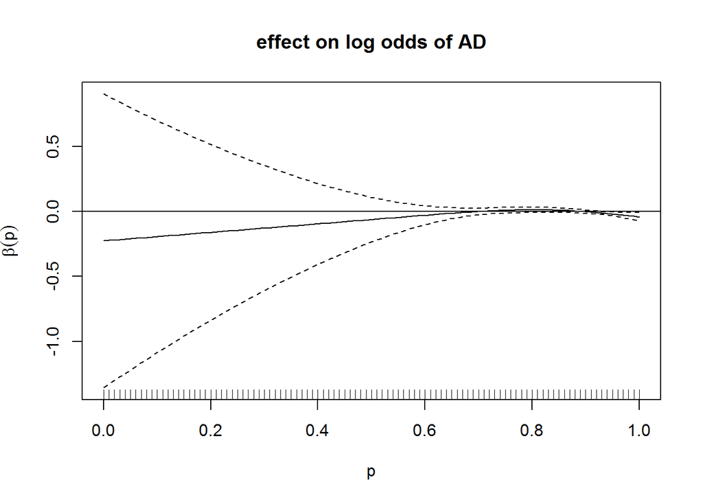

```r
plot(fit.lf,xlab="p",ylab=expression(paste(beta(p))),,main="effect on log odds of AD")
abline(h=0)
```

The effect of the subject specific quantile functions is reported to be significant and from the estimated plot it seem to be discriminaive in the upper tails, although the upper confidence limit seems to be very close to zero. Restricting the domain of $Q_i(p)$ to $p>0.5$ might be recommended here as majority of the observations below quantile level $p=0.5$ are zero, which is reflected in large standard error of the estimated coefficient function for $p<0.5$

Next we fit SOFR, modelling the cognitive scores as linear functional of $Q_i(p)$ and adjusting for age,sex and education. The results from the model fit and the estimated coefficient functions are reported below.

```
##
## Family: gaussian
## Link function: identity
##
## Formula:
## ATTN ~ age + Sex + education + s(x = actmat.tmat, by = L.actmat,
##     k = 12, bs = "ps", m = 2)
##
## Parametric coefficients:
##              Estimate Std. Error t value Pr(>|t|)
## (Intercept) -2.045394   0.926871  -2.207  0.02999 *
## age          0.006261   0.010542   0.594  0.55414
## Sex         -0.442851   0.148471  -2.983  0.00372 **
## education    0.072513   0.022781   3.183  0.00203 **
## ---
## Signif. codes:  0 '***' 0.001 '**' 0.01 '*' 0.05 '.' 0.1 ' ' 1
##
## Approximate significance of smooth terms:
##                         edf Ref.df     F p-value
## s(actmat.tmat):L.actmat   2      2 4.196  0.0182 *
## ---
## Signif. codes:  0 '***' 0.001 '**' 0.01 '*' 0.05 '.' 0.1 ' ' 1
##
## R-sq.(adj) =  0.218   Deviance explained = 26.1%
## -REML = 110.59  Scale est. = 0.46944   n = 92
```

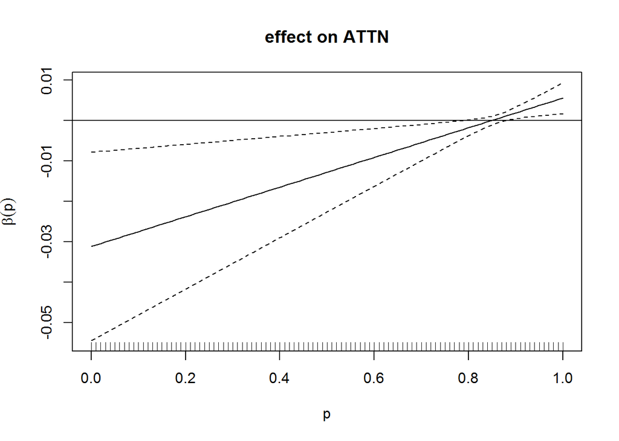

```
##
## Family: gaussian
## Link function: identity
##
## Formula:
## VM ~ age + Sex + education + s(x = actmat.tmat, by = L.actmat,
##     k = 12, bs = "ps", m = 2)
##
## Parametric coefficients:
##               Estimate Std. Error t value Pr(>|t|)
## (Intercept) -3.6347972  1.9479836  -1.866  0.06546 .
## age          0.0006823  0.0221559   0.031  0.97551
## Sex         -1.5334448  0.3120373  -4.914 4.22e-06 ***
## education    0.1422384  0.0478784   2.971  0.00385 **
## ---
## Signif. codes:  0 '***' 0.001 '**' 0.01 '*' 0.05 '.' 0.1 ' ' 1
##
## Approximate significance of smooth terms:
##                         edf Ref.df     F  p-value
## s(actmat.tmat):L.actmat   2      2 9.217 0.000229 ***
## ---
## Signif. codes:  0 '***' 0.001 '**' 0.01 '*' 0.05 '.' 0.1 ' ' 1
##
## R-sq.(adj) =  0.375   Deviance explained = 40.9%
## -REML = 174.46  Scale est. = 2.0735    n = 92
```

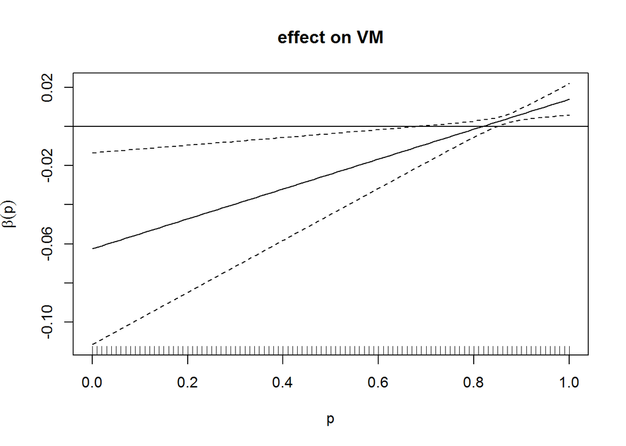

```
##
## Family: gaussian
## Link function: identity
##
## Formula:
## ExecFunction ~ age + Sex + education + s(x = actmat.tmat, by = L.actmat,
##     k = 12, bs = "ps", m = 2)
##
## Parametric coefficients:
##              Estimate Std. Error t value Pr(>|t|)
## (Intercept) -3.069835   1.530581  -2.006 0.048035 *
## age          0.004036   0.017408   0.232 0.817200
## Sex         -1.141271   0.245176  -4.655 1.17e-05 ***
## education    0.131567   0.037619   3.497 0.000746 ***
## ---
## Signif. codes:  0 '***' 0.001 '**' 0.01 '*' 0.05 '.' 0.1 ' ' 1
##
## Approximate significance of smooth terms:
##                         edf Ref.df    F p-value
## s(actmat.tmat):L.actmat   2      2 5.78 0.00438 **
## ---
## Signif. codes:  0 '***' 0.001 '**' 0.01 '*' 0.05 '.' 0.1 ' ' 1
##
## R-sq.(adj) =  0.347   Deviance explained = 38.3%
## -REML = 153.72  Scale est. = 1.2801    n = 92
```

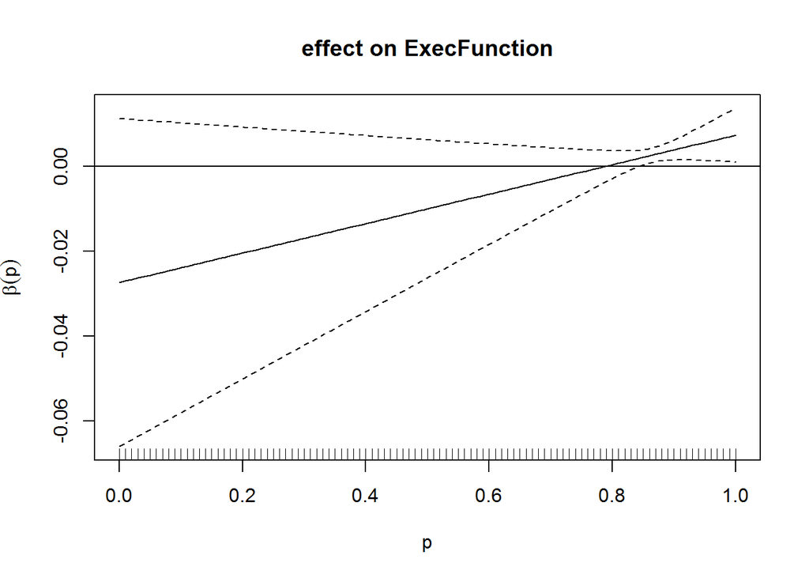

**Results**

It can be noticed we achieve similar predictive performance in terms of adjusted $R^2$ of the models as using the diurnal SD activity profiles. The plot of the coefficient functions suggest it’s the upper quantiles which have a significant and positive effect on the cognitive scores.

## 9.2 Extension

Next, we try a SOFR model of cognitive scores using both the subject specific quantile functions $Q_i(p)$ as well as the diurnal SD profiles $S_i(t)$ as predictors, as they could both contain potentially unique information.

```
##
## Family: gaussian
## Link function: identity
##
## Formula:
## ATTN ~ age + Sex + education + s(x = actmat.tmat, by = L.actmat,
##     k = 12, bs = "ps", m = 2) + s(x = sd.tmat, by = L.sd, k = 12,
##     bs = "ps", m = 2)
##
## Parametric coefficients:
##             Estimate Std. Error t value Pr(>|t|)
## (Intercept) -3.21530    1.01929  -3.154  0.00224 **
## age          0.01835    0.01125   1.631  0.10679
## Sex         -0.45636    0.14102  -3.236  0.00174 **
## education    0.06099    0.02192   2.782  0.00669 **
## ---
## Signif. codes:  0 '***' 0.001 '**' 0.01 '*' 0.05 '.' 0.1 ' ' 1
##
## Approximate significance of smooth terms:
##                           edf Ref.df     F p-value
## s(actmat.tmat):L.actmat 2.782  3.103 4.763 0.00369 **
## s(sd.tmat):L.sd         2.509  2.856 4.687 0.00544 **
## ---
## Signif. codes:  0 '***' 0.001 '**' 0.01 '*' 0.05 '.' 0.1 ' ' 1
##
## R-sq.(adj) =  0.311   Deviance explained = 37.3%
## -REML = 119.82  Scale est. = 0.41395   n = 92
```

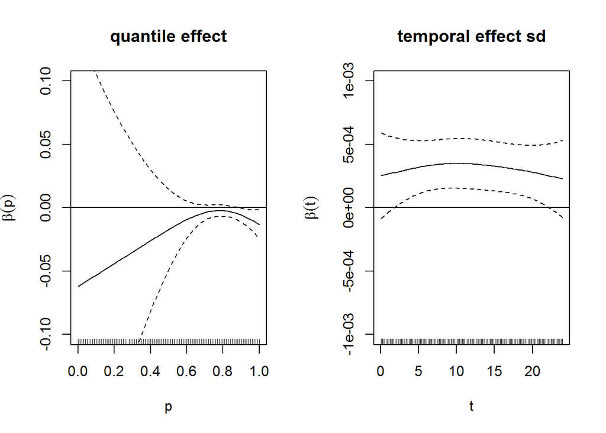

```
##
## Family: gaussian
## Link function: identity
##
## Formula:
## VM ~ age + Sex + education + s(x = actmat.tmat, by = L.actmat,
##     k = 12, bs = "ps", m = 2) + s(x = sd.tmat, by = L.sd, k = 12,
##     bs = "ps", m = 2)
##
## Parametric coefficients:
##              Estimate Std. Error t value Pr(>|t|)
## (Intercept) -3.916169   2.286660  -1.713   0.0905 .
## age          0.003277   0.025275   0.130   0.8972
## Sex         -1.524956   0.316605  -4.817 6.39e-06 ***
## education    0.135184   0.049165   2.750   0.0073 **
## ---
## Signif. codes:  0 '***' 0.001 '**' 0.01 '*' 0.05 '.' 0.1 ' ' 1
##
## Approximate significance of smooth terms:
##                         edf Ref.df     F p-value
## s(actmat.tmat):L.actmat   2      2 1.131   0.328
## s(sd.tmat):L.sd           2      2 0.310   0.735
##
## R-sq.(adj) =  0.364   Deviance explained = 41.3%
## -REML = 187.25  Scale est. = 2.1074    n = 92
```

```
##
## Family: gaussian
## Link function: identity
##
## Formula:
## ExecFunction ~ age + Sex + education + s(x = actmat.tmat, by = L.actmat,
##     k = 12, bs = "ps", m = 2) + s(x = sd.tmat, by = L.sd, k = 12,
##     bs = "ps", m = 2)
##
## Parametric coefficients:
##             Estimate Std. Error t value Pr(>|t|)
## (Intercept) -4.24378    1.74919  -2.426  0.01740 *
## age          0.01541    0.01933   0.797  0.42757
## Sex         -1.14070    0.24219  -4.710 9.69e-06 ***
## education    0.11514    0.03761   3.061  0.00296 **
## ---
## Signif. codes:  0 '***' 0.001 '**' 0.01 '*' 0.05 '.' 0.1 ' ' 1
##
## Approximate significance of smooth terms:
##                         edf Ref.df     F p-value
## s(actmat.tmat):L.actmat   2      2 0.869  0.4232
## s(sd.tmat):L.sd           2      2 2.638  0.0773 .
## ---
## Signif. codes:  0 '***' 0.001 '**' 0.01 '*' 0.05 '.' 0.1 ' ' 1
##
## R-sq.(adj) =  0.371   Deviance explained = 41.9%
## -REML = 164.74  Scale est. = 1.2331    n = 92
```

## 9.3 Summary

We observe a improved performance for cognitive scores of ATTN (around $47\%$ increase in adjusted $R^2$ from SD activity or subject-specific quantile function model), for rest of the cognitive scores, the performance is similar. The estimated coefficient function for temporal effect show the 5 a.m to 8 p.m window to have significant effect on cognitve scores of ATTN. For the linear functional effect $\beta(p)$, the upper tail is shown to be significant for ATTN. In particular, the estimated effect is negative in the upper quantile, which is interesting and might be attributed to interaction with temporal effects.

# 10 MFPCA Analysis

Next we apply multi-level functional principal component analysis (MFPCA) to minute level actigraphy data and derive the subject-specific and day-specific scores to quantify their association with cognitive status. We use the “mfpca.sc” function in refund package for implementing MFPCA.

```r
#### Codeblock for processing data for MFPCA shown below ######
library(ActCR)
path <- "E:/JHUPD/Deliverables/data/data/minute-csv"
setwd(path)
#minute level raw data for each participant
filelist<-list.files("E:/JHUPD/Deliverables/data/data/minute-csv")
myfiles <-lapply(filelist, read.csv)
subjdf<-matrix(0,nrow = 92,ncol=5)
subjdf<-as.data.frame(subjdf)
actmatlist<-list()

for(i in 1:92)
{
  mydata<-myfiles[[i]]
  mydata$ADStatus<-ifelse(mydata$ADStatus=="Yes",1,0)
  mydata$Sex<-ifelse(mydata$Sex=="Male",1,0)
  #Date, Time , Vector.Magnitude
  subdata<-mydata[,c("Date","Time","Vector.Magnitude")]
  library(chron)
  subdata$Time<-60 * 24 * as.numeric(times(subdata$Time))
  subdata$Date<-as.factor(subdata$Date)
  n<-nlevels(subdata$Date)
  actmatlist[[i]]<- matrix(0,nrow = n,ncol=144)
  datelev<-levels(subdata$Date)
  tbtick<-seq(0,1440,by=10)
  actvec<-c()
  l=length(tbtick)-1
  for(k in 1:n){
    for (j in 1:l)
    {
      tempdataj<-subdata[ subdata$Date==datelev[k]&subdata$Time>=tbtick[j]&subdata$Time <tbtick[j+1],]
actmatlist[[i]][k,j]<-mean(tempdataj$Vector.Magnitude,na.rm =TRUE)
    }
  }
 actmatlist[[i]][is.nan(actmatlist[[i]])]=NA
  ##replacing NA with mean
  for(s in 1:ncol(actmatlist[[i]])){
    actmatlist[[i]][is.na(actmatlist[[i]][,s]), s] <- mean(actmatlist[[i]][,s], na.rm = TRUE)
  }

  subjdf[i,]<-c(mydata$id[1],mydata$Age[1],mydata$ADStatus[1],mydata$Sex[1],mydata$YearsOfEducation[1])
}
names(subjdf)<-c("id","age","adstatus","Sex","education")
summary(subjdf)
```

```
##        id              age           adstatus           Sex
##  Min.   :  2.00   Min.   :60.00   Min.   :0.0000   Min.   :0.0000
##  1st Qu.: 31.75   1st Qu.:67.75   1st Qu.:0.0000   1st Qu.:0.0000
##  Median : 57.50   Median :74.00   Median :0.0000   Median :0.0000
##  Mean   : 55.84   Mean   :73.36   Mean   :0.4239   Mean   :0.4783
##  3rd Qu.: 80.25   3rd Qu.:78.00   3rd Qu.:1.0000   3rd Qu.:1.0000
##  Max.   :103.00   Max.   :92.00   Max.   :1.0000   Max.   :1.0000
##    education
##  Min.   :-999.000
##  1st Qu.:  14.000
##  Median :  16.000
##  Mean   :   5.522
##  3rd Qu.:  18.250
##  Max.   :  25.000
```

```r
subjdf[2,]$education<-c(NA)
idvec<-c()
for (i in 1:92)
{idvec<-c(idvec,rep(subjdf$id[i],nrow(actmatlist[[i]])))}

Y<-Reduce(rbind,actmatlist) #932*144
tbtick<-seq(0,1440,by=10)
binmid<-tbtick+5
binmid<-binmid[-145]
```

We use mpfca.sc function in the refund package for implementation.

```r
library(refund)
mfpcafit =  mfpca.sc(Y=Y, id = idvec, twoway = TRUE)
```

We obtain the level-1 and level-2 subject-specific and day-specific scores.

```r
load("mfpcafit.RData")
lev1score<-mfpcafit$scores$level1
lev2score<-mfpcafit$scores$level2
dim(lev1score)
```

```
## [1] 92  7
```

```r
dim(lev2score)
```

```
## [1] 932   7
```

The level-1 and level-2 eigenfunctions are displayed below.

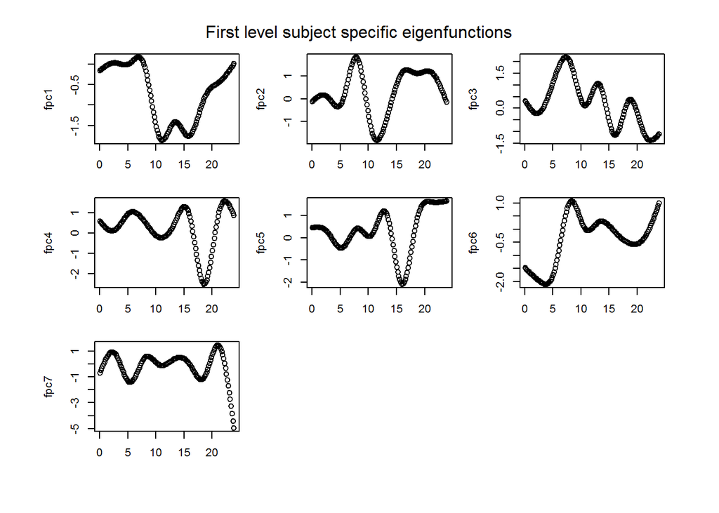

```r
par(mfrow=c(3,3))
par(oma=c(3,3,3,3),mar=c(3,4,1,1))
#level1ef
plot(binmid/60,mfpcafit$efunctions$level1[,1],xlab = "hour",ylab = "fpc1")
plot(binmid/60,mfpcafit$efunctions$level1[,2],xlab = "hour",ylab = "fpc2")
plot(binmid/60,mfpcafit$efunctions$level1[,3],xlab = "hour",ylab = "fpc3")
plot(binmid/60,mfpcafit$efunctions$level1[,4],xlab = "hour",ylab = "fpc4")
plot(binmid/60,mfpcafit$efunctions$level1[,5],xlab = "hour",ylab = "fpc5")
plot(binmid/60,mfpcafit$efunctions$level1[,6],xlab = "hour",ylab = "fpc6")
plot(binmid/60,mfpcafit$efunctions$level1[,7],xlab = "hour",ylab = "fpc7")
mtext("First level subject specific eigenfunctions",side=3,line=0,outer=TRUE)

par(mfrow=c(3,3))
```

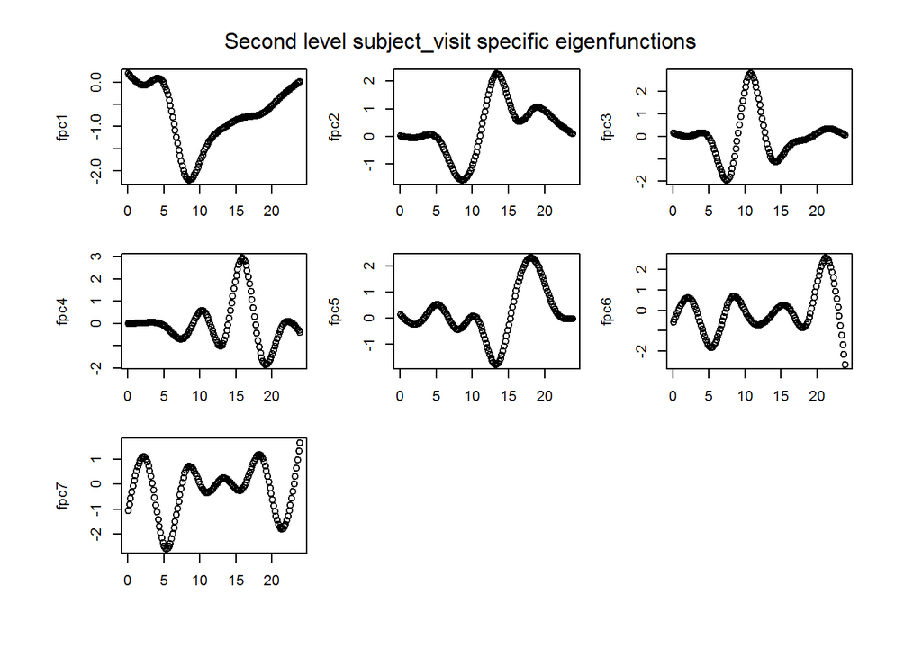

```r
par(oma=c(3,3,3,3),mar=c(3,4,1,1))
#level2ef
plot(binmid/60,mfpcafit$efunctions$level2[,1],xlab = "hour",ylab = "fpc1")
plot(binmid/60,mfpcafit$efunctions$level2[,2],xlab = "hour",ylab = "fpc2")
plot(binmid/60,mfpcafit$efunctions$level2[,3],xlab = "hour",ylab = "fpc3")
plot(binmid/60,mfpcafit$efunctions$level2[,4],xlab = "hour",ylab = "fpc4")
plot(binmid/60,mfpcafit$efunctions$level2[,5],xlab = "hour",ylab = "fpc5")
plot(binmid/60,mfpcafit$efunctions$level2[,6],xlab = "hour",ylab = "fpc6")
plot(binmid/60,mfpcafit$efunctions$level2[,7],xlab = "hour",ylab = "fpc7")
mtext("Second level subject_visit specific eigenfunctions",side=3,line=0,outer=TRUE)
```

The first eigenfunction of both level-1 and level-2 captures the mean trajectory while the other eigenfunctions capture different contrasts. Next, we use the subject-specific scores and mean and standard deviation of day-specific scores (level-2) in generalized linear model to quantify their association with cognitive status (AD/CNC).

```r
load("mfpcafit.RData") ##fitted mfpca data
lev1score<-mfpcafit$scores$level1
lev2score<-mfpcafit$scores$level2
##get mean and sd of level2 score for each subject
dfvisitspec<-matrix(0,92,2)
for (i in 1:92)
{ind<-which(idvec==subjdf$id[i])
  tempscorev<-as.vector(lev2score[ind,])
  dfvisitspec[i,1]<-mean(tempscorev)
  dfvisitspec[i,2]<-sd(tempscorev)
}
subjdf<-cbind(subjdf,lev1score) ##adding level 1 scores
subjdf$education[2]<-mean(subjdf$education,na.rm=TRUE)
names(subjdf)[6:12]<-paste("level1sc",1:7,sep="")
subjdf<-subjdf[,-1]
names(subjdf)
```

```
##  [1] "age"       "adstatus"  "Sex"       "education" "level1sc1" "level1sc2"
##  [7] "level1sc3" "level1sc4" "level1sc5" "level1sc6" "level1sc7"
```

```r
subjdf<-cbind(subjdf,dfvisitspec) ##adding level2 scores
names(subjdf)[12:13]<-c("mean_visit","sd_visit")
fitglm_mfpca <- glm(adstatus~.,data = subjdf,family="binomial")
tab_model(glm1,fitglm_mfpca,title = "Modelling cognitive status using MFPCA of activity data")
```

Modelling cognitive status using MFPCA of activity data

|  | adstatus |  |  | adstatus |  |  |
| --- | --- | --- | --- | --- | --- | --- |
| Predictors | Odds Ratios | CI | p | Odds Ratios | CI | p |
| (Intercept) | 62.64 | 0.21 – 25972.79 | 0.163 | 2291.09 | 0.95 – 14759154.74 | 0.063 |
| age | 0.98 | 0.91 – 1.04 | 0.480 | 0.94 | 0.86 – 1.02 | 0.167 |
| sex | 7.10 | 2.72 – 20.36 | **<0.001** |  |  |  |
| education | 0.80 | 0.66 – 0.93 | **0.008** | 0.81 | 0.64 – 0.99 | 0.052 |
| Sex |  |  |  | 15.99 | 4.27 – 76.46 | **<0.001** |
| level1sc1 |  |  |  | 1.00 | 1.00 – 1.01 | 0.586 |
| level1sc2 |  |  |  | 0.99 | 0.97 – 1.00 | 0.095 |
| level1sc3 |  |  |  | 0.99 | 0.97 – 1.01 | 0.238 |
| level1sc4 |  |  |  | 0.99 | 0.96 – 1.02 | 0.426 |
| level1sc5 |  |  |  | 1.03 | 1.01 – 1.06 | **0.018** |
| level1sc6 |  |  |  | 0.99 | 0.90 – 1.08 | 0.809 |
| level1sc7 |  |  |  | 1.04 | 0.97 – 1.12 | 0.247 |
| mean_visit |  |  |  | 0.99 | 0.94 – 1.03 | 0.589 |
| sd_visit |  |  |  | 0.98 | 0.95 – 1.00 | 0.062 |
| Observations | 92 |  |  | 92 |  |  |
| R<sup>2</sup> Tjur | 0.248 |  |  | 0.409 |  |  |

**Takeaway**

We note the fpc5 subject-specific score and sd of visit-specific scores are significant at $\alpha=0.1$ level and provide higher Tjur’s $R^2$ (pseudo $R^2$ for GLM) compared to a benchmark model on age,sex and education.

# 11 Summary of Work

- Cosinor Modelling of Actigraphy data shows the subject specific cosinor parameters mesor and amplitude are found to be discriminative of AD and CNC and associated with cognitive performance.
- IV (intradaily variability), a nonparametric metric representing fragmentation of circadian rhtymicity is found to be discriminative of AD and CNC and associated with cognitive performance.
- FOSR analysis shows the AD samples to have significantly lower levels of diurnal mean activity and compared to cognitively normal controls during 8 a.m-4 p.m.
- SOFR analysis shows the effect of diurnal mean activity to be significant for cognitive scores of verbal memory and executive function and significant positive effects between 8 a.m to 3 p.m indicating higher levels of cognitive performance is associated with higher levels of daily mean activity in this window.
- AD samples are found to have significantly lower levels of diurnal SD activity (representing variability in daily activity levels) from 8 a.m to 5 p.m compared to cognitively normal controls.
- SOFR analysis shows the effect of diurnal SD activity to be significant for all the three cognitive scores (representing cognitive performance) during 8 a.m to 3 p.m.
- SOFR analysis using subject specific quantile functions $Q_i(p)$ of activity counts suggest it’s the upper quantiles which have the most significant effects on the cognitive scores and most discriminative of AD.
- Our analysis indicates possible interaction between the distributional domain $p$ and temporal domain $t$, it would be interesting to take their joint contribution into account while modelling continuous actigraphy data and this remains an area to be explored in future research.
- Multilevel Functional prinicipal component analysis (MFPCA) of Actigraphy data shows the subject specific fpc5 score and standard deviation of visit-specific scores to be significant and discriminative of AD.